# CIND 123 - Data Analytics: Basic Methods

Marco Muto

# Assignment 2 (10%)

## Instructions

Use RStudio for this assignment. Complete the assignment by inserting your R code wherever you see the string “#INSERT YOUR ANSWER HERE”.

Submit **both** the rmd and generated output files. Failing to submit both files will be subject to mark deduction.

## Sample Question and Solution

Use `seq()` to create the vector $(1,2,3,\ldots,20)$.

```r
seq(1,20)
```

```
##  [1]  1  2  3  4  5  6  7  8  9 10 11 12 13 14 15 16 17 18 19 20
```

## Question 1

The Titanic Passenger Survival DataSet provides information on the fate of passengers on the fatal maiden voyage of the ocean liner “Titanic.” The dataset is available from the Department of Biostatistics at the Vanderbilt University School of Medicine (http://biostat.mc.vanderbilt.edu/wiki/pub/Main/DataSets/titanic3.csv)in several formats. store the Titanic DataSet `titanic_train` using the following commands.

```r
library(titanic)
titanicDataset <- read.csv(file = "http://biostat.mc.vanderbilt.edu/wiki/pub/Main/DataSets/titanic3.csv", stringsAsFactors = F)
summary(titanicDataset)
```

```
##      pclass         survived         name               sex
##  Min.   :1.000   Min.   :0.000   Length:1309        Length:1309
##  1st Qu.:2.000   1st Qu.:0.000   Class :character   Class :character
##  Median :3.000   Median :0.000   Mode  :character   Mode  :character
##  Mean   :2.295   Mean   :0.382
##  3rd Qu.:3.000   3rd Qu.:1.000
##  Max.   :3.000   Max.   :1.000
##
##       age            sibsp            parch          ticket
##  Min.   : 0.17   Min.   :0.0000   Min.   :0.000   Length:1309
##  1st Qu.:21.00   1st Qu.:0.0000   1st Qu.:0.000   Class :character
##  Median :28.00   Median :0.0000   Median :0.000   Mode  :character
##  Mean   :29.88   Mean   :0.4989   Mean   :0.385
##  3rd Qu.:39.00   3rd Qu.:1.0000   3rd Qu.:0.000
##  Max.   :80.00   Max.   :8.0000   Max.   :9.000
##  NA's   :263
##       fare            cabin             embarked             boat
##  Min.   :  0.000   Length:1309        Length:1309        Length:1309
##  1st Qu.:  7.896   Class :character   Class :character   Class :character
##  Median : 14.454   Mode  :character   Mode  :character   Mode  :character
##  Mean   : 33.295
##  3rd Qu.: 31.275
##  Max.   :512.329
##  NA's   :1
##       body        home.dest
##  Min.   :  1.0   Length:1309
##  1st Qu.: 72.0   Class :character
##  Median :155.0   Mode  :character
##  Mean   :160.8
##  3rd Qu.:256.0
##  Max.   :328.0
##  NA's   :1188
```

1. Extract the columns `sex`, `age`, `cabin` and `survived` into a new data frame of the name ‘titanicSubset’.

```r
titanicSubset <- subset(titanicDataset,select = c("sex","age","cabin","survived"))
head(titanicSubset)
```

```
##      sex   age   cabin survived
## 1 female 29.00      B5        1
## 2   male  0.92 C22 C26        1
## 3 female  2.00 C22 C26        0
## 4   male 30.00 C22 C26        0
## 5 female 25.00 C22 C26        0
## 6   male 48.00     E12        1
```

2. Use the aggregate() function to display the total number of survivors grouped by `sex`

```r
##i converted the integer data type to numeric so the aggregate function could work
titanicSubset <- transform(titanicSubset,survived=as.numeric(survived))


aggregate(survived~sex,titanicSubset,sum)
```

```
##      sex survived
## 1 female      339
## 2   male      161
```

3. Use the count() function in `dplyr` package to display the total number of passengers within each Ticket Class `Pclass.`

```r
library(dplyr)
titanicDataset %>% group_by(pclass) %>% count()
```

```
## # A tibble: 3 x 2
## # Groups:   pclass [3]
##   pclass     n
##    <int> <int>
## 1      1   323
## 2      2   277
## 3      3   709
```

4. Answer the following graphically:
1. What was the survival rates for females and males?
2. What was the age distribution on the Titanic?

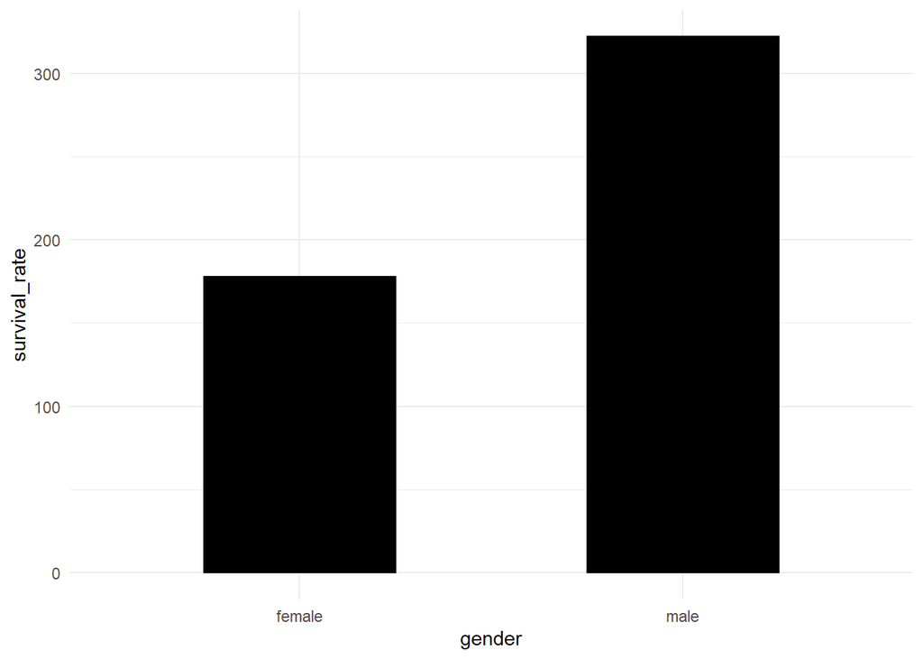

```r
## 1.)
library(ggplot2)
library(dplyr)
surv<- titanicDataset %>%
select(sex,survived)  %>%
group_by(sex)
srate <-sum(surv$survived)/length(surv$survived)
d<-ggplot(data=surv,aes(x=sex,
                        y=srate

))
d+geom_bar(stat = "identity",width = 0.5,color = "black",size=0.5,alpha=0.7)+theme_minimal()+labs(x="gender",y="survival_rate")
```

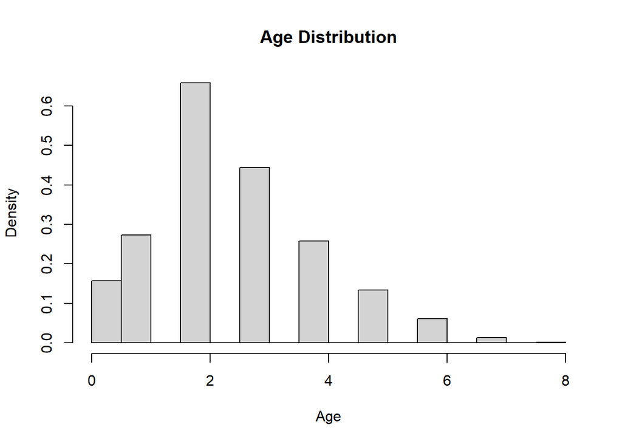

```r
##2.)
titanicAGE <- subset(titanicDataset,select = c("age"))
titanicAGE2<-na.omit(titanicAGE)

g<-findInterval(sapply(titanicAGE2, as.numeric),c(10,20,30,40,50,60,70,80,90))
hist(g,freq = F,xlab = "Age",main = "Age Distribution")
     legend(4,9,c("1:0-10"))
```

e)Use the `for` loop and `if` control statements to list the children’s names, aged 14 or under, on the Titanic.

```r
a <- character()

for (row in 1:nrow(titanicDataset)){ # iterate over the rows in the dataframe, not the ages like in the for loop you tried
  if (titanicDataset[row, "age"] <= 14 & !is.na(titanicDataset[row, "age"])) {
  # if the age value in a row is less than or equal to 14 and not NA, add the name from that row to "a"

    a <- c(a, titanicDataset[row, "name"])

  } else { # if not, do nothing

  }
}
print(a)
```

```
##   [1] "Allison, Master. Hudson Trevor"
##   [2] "Allison, Miss. Helen Loraine"
##   [3] "Carter, Master. William Thornton II"
##   [4] "Carter, Miss. Lucile Polk"
##   [5] "Dodge, Master. Washington"
##   [6] "Ryerson, Master. John Borie"
##   [7] "Spedden, Master. Robert Douglas"
##   [8] "Becker, Master. Richard F"
##   [9] "Becker, Miss. Marion Louise"
##  [10] "Becker, Miss. Ruth Elizabeth"
##  [11] "Caldwell, Master. Alden Gates"
##  [12] "Collyer, Miss. Marjorie \"Lottie\""
##  [13] "Davies, Master. John Morgan Jr"
##  [14] "Drew, Master. Marshall Brines"
##  [15] "Hamalainen, Master. Viljo"
```

[output cut: 92 more lines]

## Question 2

In an experiment of rolling 10 dice simultaneously. Use the binomial distribution to calculate the followings:

1. The probability of getting six 6’s

```r
dbinom(x=6,p=1/6,size = 10, log = F)
```

```
## [1] 0.002170635
```

```r
choose(10,6)*(1/6)^6*(5/6)^4 #just checking my work
```

```
## [1] 0.002170635
```

2. The probability of getting six, seven, or eight 3’s

```r
eight3<-dbinom(x=8,p=1/6,size = 10,log=F)
seven3<-dbinom(x=7,p=1/6,size = 10,log=F)
six3<-dbinom(x=6,p=1/6,size = 10,log=F)
data.frame(eight3,seven3,six3)
```

```
##         eight3       seven3        six3
## 1 1.860544e-05 0.0002480726 0.002170635
```

3. The probability of getting six even numbers

```r
dbinom(x=6,p=1/3,size = 10,log=F)
```

```
## [1] 0.0569019
```

## Question 3

In a shipment of 20 engines, history shows that the probability of any one engine proving unsatisfactory is 0.1

1. Use the Binomial approximation to calculate the probability that at least three engines are defective?

```r
##dbinom(x=3,size = 20,prob = 0.1, log =F)

mui<-20*0.1
s<-sqrt(20*0.1*0.9)
z<-3-mui/s
print(z)
```

```
## [1] 1.509288
```

2. Use the Poisson approximation to calculate the probability that at least three engines are defective?

```r
ppois(q=3,lambda = 2,lower.tail = F)
```

```
## [1] 0.1428765
```

3. Compare the results of parts a and b, then illustrate graphically on how well the Poisson probability distribution approximates the Binomial probability distribution.

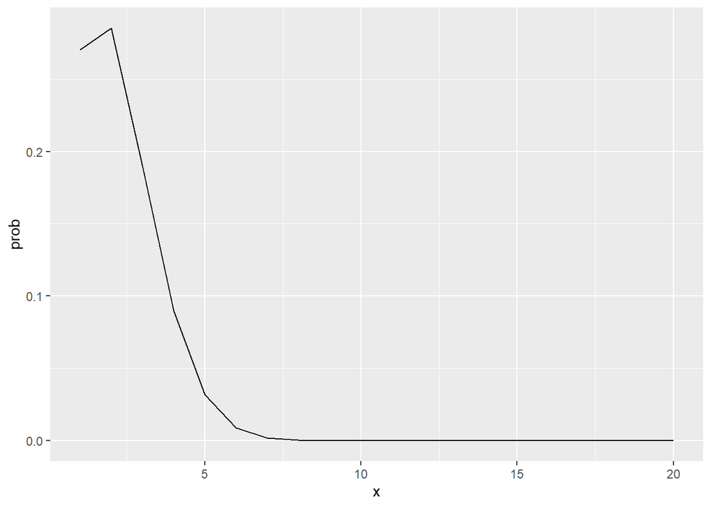

```r
df <- data.frame(x=1:20,prob=dbinom(x=1:20,size = 20,prob = 0.1, log =F))
require(ggplot2)
ggplot(data=df, aes(x=x,y=prob)) + geom_line()
```

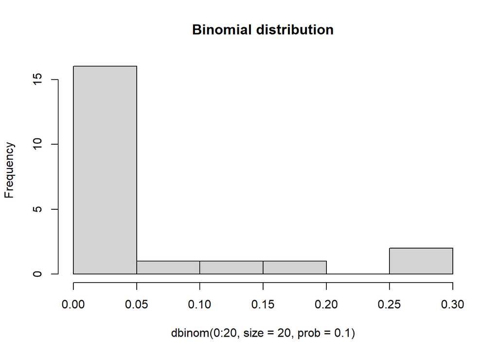

```r
#alternative
hist(dbinom(0:20,size = 20,prob = 0.1), main = "Binomial distribution")
```

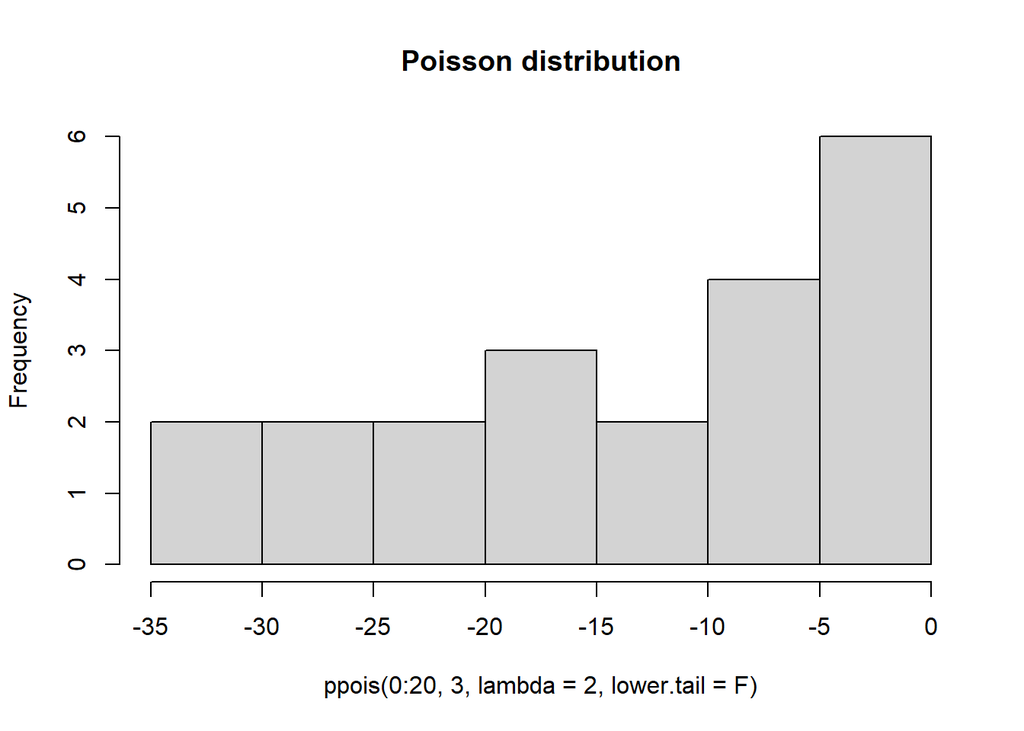

```r
hist(ppois(0:20,3,lambda = 2,lower.tail = F),main = "Poisson distribution")
```

## Question 4

Write a script in R to compute the following probabilities of a normal random variable with mean 16 and variance 9

1. lies between 14.4 and 20.3 (inclusive)

```r
z1<-(14.4-16)/sqrt(9)
z2<-(20.3-16)/sqrt(9)
print(z1) ##from table 0.29806
```

```
## [1] -0.5333333
```

```r
print(z2) ##from table 0.92364
```

```
## [1] 1.433333
```

```r
print("probability between the area")
```

```
## [1] "probability between the area"
```

```r
print(0.92364-0.29896)
```

```
## [1] 0.62468
```

```r
pnorm(q=21.3,mean=16,sd=9^0.5,lower.tail=F)
```

```
## [1] 0.03864203
```

3. is less or equal to 10.5

```r
pnorm(q=10.5,mean = 16, sd=9^0.5,lower.tail = T)
```

```
## [1] 0.03337651
```

4. is less than 13 or greater than 19

```r
pnorm(q=13,mean = 16,sd=9^0.5,lower.tail = T) + pnorm(q=19,mean = 16,sd=9^0.5,lower.tail = F)
```

```
## [1] 0.3173105
```

END of Assignment #2.